# Manuscript 3 - Stroke Caregiver Burden Bibliometric

Research on Stroke Caregiver Burden, A bibliometric Analysis

Author

Mohd Azmi B Suliman

Published

Tuesday, 06/12/2022

# 1 Front Matter

Title: Research on Stroke Caregiver, A bibliometric Analysis

Authors:

- Mohd Azmi Bin Suliman
- Mohd Khairul Anwar Bin Kamdi
- Tengku Muhammad Hanis
- Kamarul Imran Musa

## 1.1 Abstract

**Introduction**: Stroke is a serious and growing health problem, and since most people with stroke live at home, caring responsibilities generally fall on family members. Caregivers are often inadequately supported by formal health services and have poorer psychological and physical health. Our study aimed to compare the contribution of publications from different countries, institution and authors and present a bibliometric analysis to determine the hotspots and trend in research concerning the health and interventions for family stroke caregivers

**Methods**: Studies published during 2013-2022 were extracted from the Web of Science (WOS). Each abstract of publications was evaluated to obtain the basic information. A bibliometric analysis was used to evaluate the number or cooperation networks of publications, countries, institution, journal, citations, authors, references and keywords. The resulting articles were analysed descriptively and the publication keywords were visualized using `bibliometrix` package in R.

**Conclusion**: Our study details the performance statistics, main topics and trend research on the health of and interventions for stroke caregivers from 2013-2022 and provides a comprehensive analysis.

**Keywords**: Bibliometric analysis; stroke caregivers burden; research trends

# 2 Introduction

**Note**

1 para (3-4 sentences) on stroke & stroke epidemiology

The health of caregivers can be overlooked and they have been referred to as ‘silent patients’ or ‘secondary patients’. The negative outcomes associated with caregiving include depression and anxiety, and caregivers exhibit high rates of mood disorders. The heavy burden and psychological distress caused by caring for relative with dementia may also contribute to severe physical and psychiatric problems and higher mortality risk. Recognizing this need, interventions have been developed to address the negative effect of caregiving, including education, respite, psychotherapeutic, family support, and multicomponent approaches. In recent decades, the research on this topic has covered a wide spectrum. However, a detailed analysis if the existing research publication landscape has not been undertaken to elucidate the body of published evidence. Such an analysis would be helpful for delineating the global trends in the research fields related to the health of and interventions for stroke caregivers.

**Note**

1-2 para (6-8 sentences) on stroke caregiver

- epidemiology
- need for intervention

The aims of this study were to examine the publication patterns of research on stroke caregiver burden at a global level. we attempted to provide comprehensive insights into the current state of global research, including annual output characteristic, international collaborations, and keywords trends. The results should provide a better understanding of the global trends in the research on the stroke caregiver burden and indicate directions for further research.

**Note**

1 para for objectives and study justification

# 3 Methodology

The data were downloaded from public databases and as secondary data, did not require any interactions with human subjects. There were no ethical issues associated with the data, and approval from institutional review boards was not required.

The data were obtained from Web of Science on 1st December, 2022, with publications published in the between 1996 and 2022 were retrieved. The keyword used in the search were as follow: (TI=(stroke) AND TI=(caregiver) AND TI=(burden)). *Two independent researchers* conducted the research simultaneously to ensure that the search was accurate and that all relevant manuscripts were identified and included. The search result form the Web of Science database were subsequently filtered to include the article type only. A bibtex data download from the WOS included the author names, contact address, title, publication year, abstract, author keyword, journal information and cited references.

Bibliometrics is defined as the application of statistics and mathematics for the analysis of written publications such as books and journal articles. Bibliometric techniques can be used to perform statistical and quantitative analysis of publications and offer a convenient way to visibly measure researchers efforts in the investigation of a specific field. Such analyses can characterize the development in certain field and have contributed substantially to informing policy making, clinical guidelines and research trends. Impact factors were taken from those published by the WOS in 2018. Cooperation among countries or institution was based on the first authors. Collaboration type was determined by the addresses of the authors, where the term ‘single-country article’ was assigned if the researchers’ addresses were in the same country. The term ‘internationally collaborative article’ was used to designate those articles that were co-authored by researchers from multiple countries.

The data were analysed both quantitatively and qualitatively. We describe the research status of this field based on statistics regarding the number of articles and their distribution across countries and in time and space, subjects, journal, and high-yield institutions and authors. Moreover, the corpus was analysed to generate different scientific landscapes and networks. We analysed the cooperation situation in this field among countries and institutions via cooperation analysis; the intrinsic links among authors via bibliographic coupling; and the reference network and frequently cited literature via co-citation analysis. in the hotspot analysis, we captured high-frequency keywords for the clustering and co-occurrence analyses. The bibliometric analysis in this study was performed and visualized using `bibliometric` package in R and RStudio.

**Note**

update these 2 para

- methodology - what was done in analysis (i.e. the result)

# 4 Results

```r
pacman::p_load(tidyverse, bibliometrix, janitor, stringi, gtsummary, igraph,
               gtsummary, kableExtra, metagear)

bibds_wos <- convert2df(file = "22-12-06 WOS_TIstcgp10y.bib", dbsource = "wos",
                        format = "bibtex")
bibres <- biblioAnalysis(bibds_wos)
bibres_summary <- summary(bibres)

bibres_plot <- plot(bibres, k = 10)
```

```r
# error for plot

bibres_countrylist <- bibres$Countries

bibres_countrytable <- tibble(Rank = seq_along(bibres_countrylist),
                              Country = rownames(bibres_countrylist),
                              Np = as.integer(bibres_countrylist)) %>%
  mutate(Country = fct_reorder(Country, Rank))

bibressum_countrytable <- tibble(Rank = 1:10,
       bibres_summary$TCperCountries) %>%
  rename("Country" = "Country     ") %>%
  mutate(Country = str_trim(Country),
         Country = fct_reorder(Country, Rank),
         `Total Citations` = as.integer(`Total Citations`),
         `Average Article Citations` = as.double(`Average Article Citations`)) %>%
  inner_join(x = ., y = select(bibres_countrytable, Country, Np), by = "Country")

bibres_instlist <- bibres$Affiliations

bibres_insttable <- tibble(Rank = seq_along(bibres_instlist),
                           InstitutionAffiliation = rownames(bibres_instlist),
                           Np = as.integer(bibres_instlist)) %>%
  mutate(InstitutionAffiliation = fct_reorder(InstitutionAffiliation, Rank))

bibres_sourcelist <- bibres$Sources

bibres_sourcetable <- tibble(Rank = seq_along(bibres_sourcelist),
                             SourceJournal = rownames(bibres_sourcelist),
                             Np = as.integer(bibres_sourcelist)) %>%
  mutate(SourceJournal = fct_reorder(SourceJournal, Rank))

bibres_sourcetablepercent <- bibres_sourcetable %>%
  count(Np) %>%
  mutate(percent = n / sum(n) * 100,
         percent = round(percent,1))

bib_bradford <- bradford(bibds_wos)

bib_bradfordtable <- bib_bradford$table %>%
  select(Zone, Freq, Rank) %>%
  tibble() %>%
  group_by(Zone) %>%
  summarise(nSO = n(),
            nArt = sum(Freq),
            RankRange = str_c(min(Rank), max(Rank), sep = "-"))

bibds_noaufreq <- bibds_wos %>%
  select(TI, AU, DT) %>%
  tibble() %>%
  mutate(no_auth = stri_count_regex(AU, c(";")) + 1,
         DT = fct_recode(DT,
                         "ARTICLE" = "ARTICLE; PROCEEDINGS PAPER",
                         "ARTICLE" = "ARTICLE; EARLY ACCESS")) %>%
  rename("paper" = "TI", "author" = "AU", "type" = "DT") %>%
  group_by(no_auth, type) %>%
  summarise(freq = n(), .groups = "drop") %>%
  mutate(percent = freq / sum(freq) * 100,
         percent = round(percent,1))

bibres_aulist <- bibres$Authors

bibres_autable <- tibble(Rank = seq_along(bibres_aulist),
                         Author = rownames(bibres_aulist),
                         Np = as.integer(bibres_aulist)) %>%
  mutate(Author = fct_reorder(Author, Rank))

bibres_autablepercent <- bibres_autable %>%
  count(Np) %>%
  mutate(percent = n / sum(n) * 100,
         percent = round(percent,1))
```

## 4.1 General Information

```r
bibres_summary

# bibres_summary$AnnualProduction
```

<sup>1</sup> manual

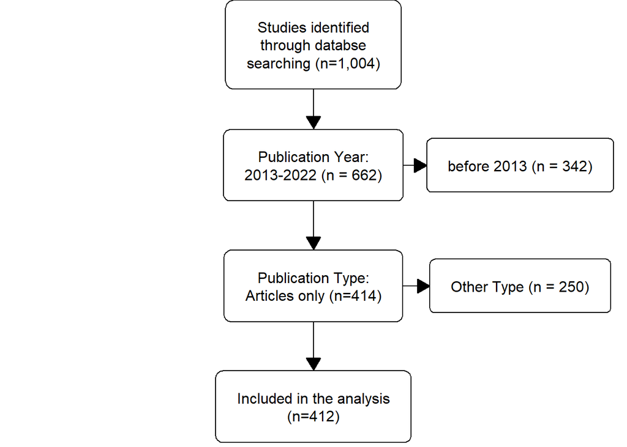

Figure 1: Flow diagram for the inclusion of publication on the stroke caregiver burden

```r
prismaplot <- plot_PRISMA(
  c("START_PHASE: Studies identified through databse searching (n=1,004)",
    "Publication Year: 2013-2022 (n = 662)",
    "EXCLUDE_PHASE: before 2013 (n = 342)",
    "Publication Type: Articles only (n=414)",
    "EXCLUDE_PHASE: Other Type (n = 250)",
    "Included in the analysis (n=412)"),
  design = "classic", colWidth = 25, excludeDistance = 1
  )
```

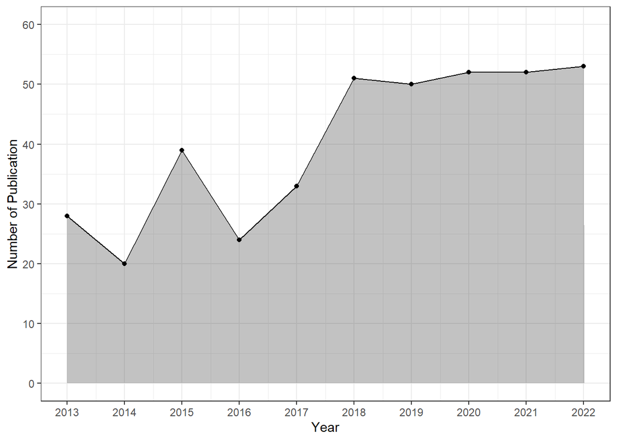

Figure 2: Number of Publications by Year

```r
# bibres_plot$AnnualScientProd
# error plot - refer setup chunk

tibble(Article = rownames(bibds_wos),
       Year = bibds_wos$PY) %>%
  group_by(Year) %>%
  summarise(n = n()) %>%
  ggplot(aes(x = Year, y = n)) +
  geom_area(alpha = .3) +
  geom_point() +
  geom_line() +
  scale_y_continuous(breaks = seq(0,60,10)) +
  scale_x_continuous(breaks = seq(2013,2022,1)) +
  coord_cartesian(ylim = c(0,60)) +
  labs(x = "Year", y = "Number of Publication") +
  theme_bw()
```

## 4.2 Country

When analysing the corresponding author’s country, the 412 articles were published in 46 countries. The top 10 productive countries, and top 10 most total citation per country were shown in Table 1.

```r
bibres_countrytable %>%
  rename("Number of Publications" = "Np") %>%
  filter(`Number of Publications` >= 12) %>%
  kable() %>% kable_classic(full_width = F)
bibressum_countrytable %>%
  relocate(Np, .after = `Total Citations`) %>%
  rename("Number of Publications" = "Np") %>%
  kable(digits = 1) %>% kable_classic(full_width = F)
```

Table 1: Publication by Country (Corresponding Author’s Country)

(a) Top 10 Productive Country

| Rank | Country | Number of Publications |
| --- | --- | --- |
| 1 | USA | 92 |
| 2 | CHINA | 61 |
| 3 | CANADA | 20 |
| 4 | TURKEY | 19 |
| 5 | NETHERLANDS | 17 |
| 6 | UNITED KINGDOM | 16 |
| 7 | BRAZIL | 15 |
| 8 | IRAN | 14 |
| 9 | SINGAPORE | 14 |
| 10 | ITALY | 12 |

(b) Top 10 Most Citation by Country

| Rank | Country | Total Citations | Number of Publications | Average Article Citations |
| --- | --- | --- | --- | --- |
| 1 | USA | 1395 | 92 | 15.2 |
| 2 | CHINA | 671 | 61 | 11.0 |
| 3 | UNITED KINGDOM | 533 | 16 | 33.3 |
| 4 | CANADA | 317 | 20 | 15.8 |
| 5 | ITALY | 239 | 12 | 19.9 |
| 6 | NETHERLANDS | 235 | 17 | 13.8 |
| 7 | AUSTRALIA | 153 | 10 | 15.3 |
| 8 | NIGERIA | 132 | 10 | 13.2 |
| 9 | KOREA | 120 | 11 | 10.9 |
| 10 | SWEDEN | 119 | 10 | 11.9 |

```r
# bibres_plot$MostProdCountries
# error plot - refer setup chunk

bibres_countrytable %>%
  filter(Rank <= 11) %>%
  ggplot(aes(x = Np, y = Country)) +
  geom_bar(stat = "identity") +
#  scale_x_continuous(breaks = seq(0,15,2)) +
  labs(x = "Number of Publications") +
  theme_bw()
```

The collaboration network between the corresponding author’s countries was shown in Figure 3.

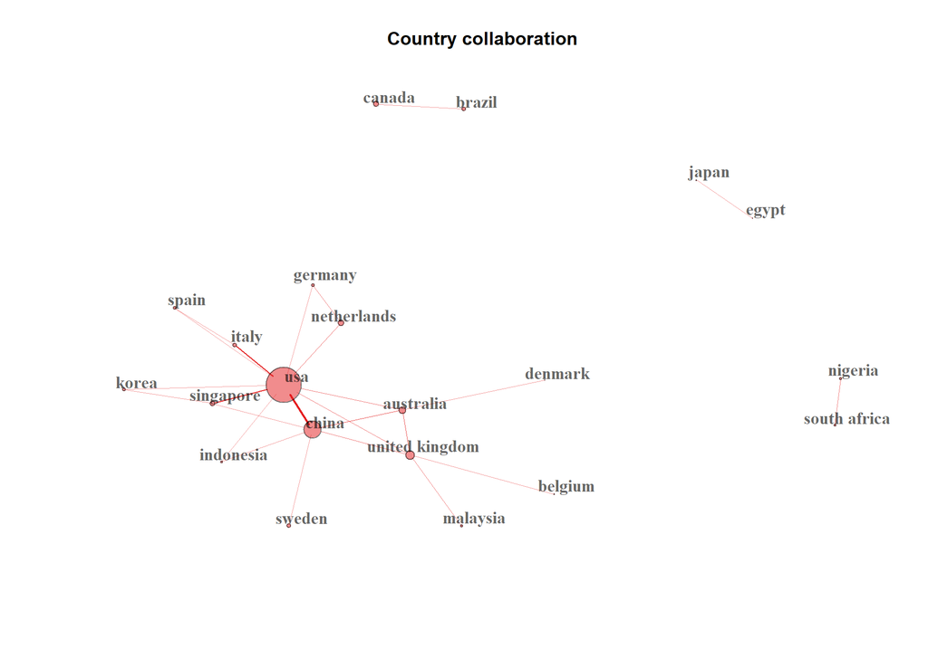

Figure 3: Countries Collaboration Map

```r
bib_concolab <- metaTagExtraction(bibds_wos, Field = "AU_CO", sep = ";")

bib_concolab_NetMatrix <- biblioNetwork(bib_concolab, analysis = "collaboration",
                                       network = "countries", sep = ";")

bib_concolab_Plot <- networkPlot(bib_concolab_NetMatrix,
                                 n = dim(bib_concolab_NetMatrix)[1],
                                 Title = "Country collaboration", type = "auto",
                                 size=10, size.cex=T, edgesize = 2, labelsize=1.1,
                                 edges.min = 2, remove.isolates = T, community.repulsion = 0,
                                 cluster = "none")
```

## 4.3 Institution

The publications in this field were from 746 institutions. The top 10 productive institutions were shown in Table 2. The collaboration network between the institution was shown in Figure 4.

```r
bibres_insttable %>%
  rename("Number of Publications" = "Np",
         "Instituion Name" = "InstitutionAffiliation") %>%
  mutate(`Instituion Name` = str_to_title(`Instituion Name`)) %>%
  filter(`Number of Publications` >= 15) %>%
  kable() %>% kable_classic(full_width = F)
```

Table 2: Most Productive Institution

| Rank | Instituion Name | Number of Publications |
| --- | --- | --- |
| 1 | Univ Toronto | 32 |
| 2 | Univ Texas Hlth Sci Ctr Houston | 30 |
| 3 | Natl Univ Singapore | 29 |
| 4 | Univ Florida | 27 |
| 5 | Maastricht Univ | 24 |
| 6 | Univ Cincinnati | 24 |
| 7 | Univ Roma Tor Vergata | 22 |
| 8 | Zhengzhou Univ | 22 |
| 9 | China Med Univ | 16 |
| 10 | Chinese Univ Hong Kong | 15 |
| 11 | Tianjin Med Univ | 15 |
| 12 | Univ Alabama Birmingham | 15 |

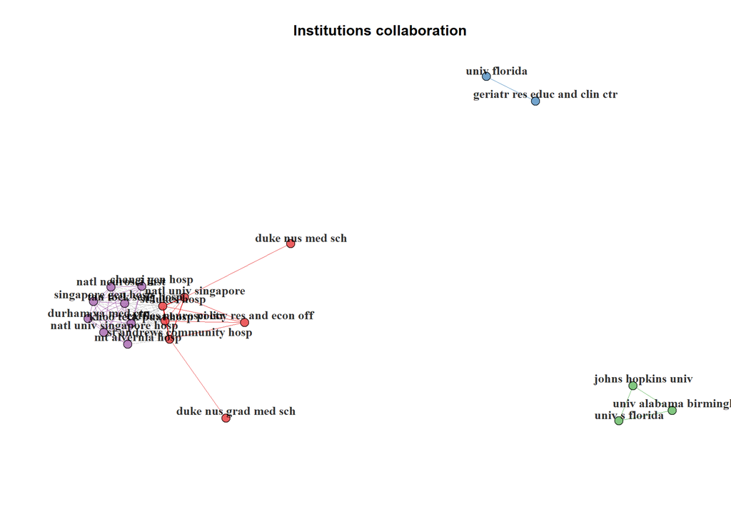

Figure 4: Institution Collaboration Map

```r
bib_educolab_NetMatrix <- biblioNetwork(bibds_wos, analysis = "collaboration",
                                       network = "universities", sep = ";")

bib_educolab_Plot <- networkPlot(bib_educolab_NetMatrix, n = 25,
                                 cluster = "optimal", type = "auto",
                                 size.cex = F, size = 3, remove.multiple = F,
                                 labelsize=1, alpha = .7, edgesize = 1,
                                 edges.min = 5, remove.isolates = T,
                                 community.repulsion = 0,
                                 Title = "Institutions collaboration")
```

## 4.4 Journals

A total of 197 journals have published articles in this field. Most of the journals only produced one article (66.5%). Based on Bradford’s Law, there were 14 journal in Zone 1, as the listed in Table 4.

```r
bib_bradfordtable %>%
rename("No of Source (Journal)" = "nSO",
       "Total Article" = "nArt",
       "Source Rank" = "RankRange")%>%
  kable() %>%
  kable_classic(full_width = F)
```

Table 3: No of Journals and Articles by Zone of Bradford’s Law

| Zone | No of Source (Journal) | Total Article | Source Rank |
| --- | --- | --- | --- |
| Zone 1 | 14 | 138 | 1-14 |
| Zone 2 | 50 | 139 | 15-64 |
| Zone 3 | 133 | 135 | 65-197 |

```r
bib_bradford$table %>%
  filter(Zone == "Zone 1") %>%
  tibble() %>%
  mutate(SO = str_to_title(SO)) %>%
  rename("Journal Name" = "SO") %>%
  kable() %>%
  kable_classic(full_width = F)
```

Table 4: Journals in Zone 1 of Bradford’s Law

| Journal Name | Rank | Freq | cumFreq | Zone |
| --- | --- | --- | --- | --- |
| Topics In Stroke Rehabilitation | 1 | 25 | 25 | Zone 1 |
| Bmj Open | 2 | 13 | 38 | Zone 1 |
| Disability And Rehabilitation | 3 | 12 | 50 | Zone 1 |
| Journal Of Neuroscience Nursing | 4 | 11 | 61 | Zone 1 |
| Rehabilitation Nursing | 5 | 10 | 71 | Zone 1 |
| Stroke | 6 | 10 | 81 | Zone 1 |
| Journal Of Advanced Nursing | 7 | 8 | 89 | Zone 1 |
| Journal Of Stroke \& Cerebrovascular Diseases | 8 | 8 | 97 | Zone 1 |
| Scandinavian Journal Of Caring Sciences | 9 | 8 | 105 | Zone 1 |
| Clinical Rehabilitation | 10 | 7 | 112 | Zone 1 |
| Journal Of Clinical Nursing | 11 | 7 | 119 | Zone 1 |
| Plos One | 12 | 7 | 126 | Zone 1 |
| International Journal Of Environmental Research And Public Health | 13 | 6 | 132 | Zone 1 |
| Medicine | 14 | 6 | 138 | Zone 1 |

```r
## label: tbl-top15journal
## tbl-cap: "Most Productive Journal"

# bibres_sourcetable %>%
#   rename("Number of Publications" = "Np",
#          "Source (Journal)" = "SourceJournal") %>%
#   mutate(`Source (Journal)` = str_to_title(`Source (Journal)`)) %>%
#   head(n = 15) %>%
#   kable() %>% kable_classic(full_width = F)
```

Journal co-citation analysis as shown in Figure 5

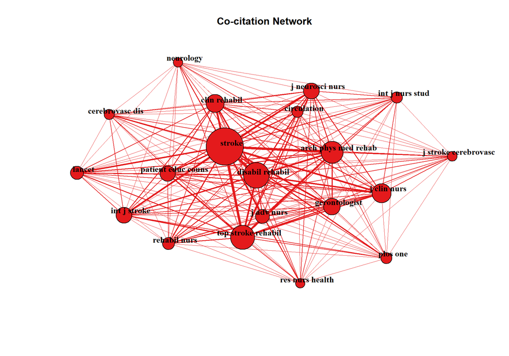

Figure 5: Journal Co-citation Analysis

```r
bib_CRSO <- metaTagExtraction(bibds_wos, Field = "CR_SO", sep = ";")
bib_CRSO_NetMatrix <- biblioNetwork(bib_CRSO, analysis = "co-citation",
                                    network = "sources", sep = ";")
bib_CRSO_Plot <- networkPlot(bib_CRSO_NetMatrix, n = 20,
                             Title = "Co-citation Network", type = "auto",
                             size.cex = T, size = 20, remove.multiple = F,
                             labelsize = 1, edgesize = 5, edges.min = 5, alpha = 1)
```

## 4.5 Authors, Articles and References

```r
bibres_autable %>%
  rename("Number of Publications" = "Np") %>%
  mutate(Author = str_to_title(Author)) %>%
  head(n = 10) %>%
  kable() %>% kable_classic(full_width = F)
```

Table 5: Most Productive Authors

| Rank | Author | Number of Publications |
| --- | --- | --- |
| 1 | Bakas T | 13 |
| 2 | Koh Gch | 11 |
| 3 | Pucciarelli G | 10 |
| 4 | Vellone E | 10 |
| 5 | Alvaro R | 9 |
| 6 | Lutz Bj | 8 |
| 7 | Matchar Db | 8 |
| 8 | Mccarthy Mj | 8 |
| 9 | Roth Dl | 8 |
| 10 | Tan By | 8 |

The articles have one to 27 authors, with majority of them had four authors (19.4%). The number of authors for each articles were summarised in Figure 6

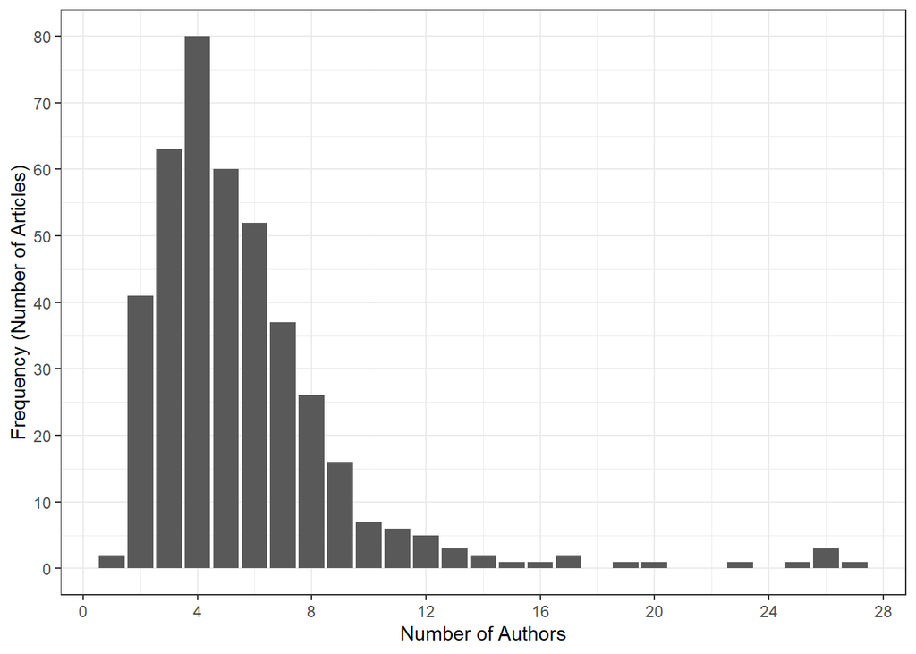

Figure 6: Number of authors per articles

```r
bibds_noaufreq %>%
  ggplot(aes(no_auth, freq)) +
  geom_bar(stat = "identity") +
  labs(x = "Number of Authors", y = "Frequency (Number of Articles)") +
  scale_x_continuous(breaks = seq(0,30,4)) +
  scale_y_continuous(breaks = seq(0,80,10)) +
  theme_bw()
```

The top 10 most cited articles as shown in Table 6

```r
tibble(Title = bibds_wos$TI,
       Author = bibds_wos$AU,
       DOI = bibds_wos$DI,
       Citations = bibds_wos$TC) %>%
  arrange(desc(Citations)) %>%
  head(n=11) %>%
  kable() %>% kable_classic()
```

Table 6: Top 10 Most Cited Articles on Stroke Caregiver Burden

| Title | Author | DOI | Citations |
| --- | --- | --- | --- |
| TOP 10 RESEARCH PRIORITIES RELATING TO LIFE AFTER STROKE - CONSENSUS FROM STROKE SURVIVORS, CAREGIVERS, AND HEALTH PROFESSIONALS | POLLOCK A;ST GEORGE B;FENTON M;FIRKINS L | 10.1111/j.1747-4949.2012.00942.x | 190 |
| POSTSTROKE SPASTICITY SEQUELAE AND BURDEN ON STROKE SURVIVORS AND CAREGIVERS | ZOROWITZ RD;GILLARD PJ;BRAININ M | 10.1212/WNL.0b013e3182764c86 | 140 |
| STROKE FAMILY CAREGIVERS' SUPPORT NEEDS CHANGE ACROSS THE CARE CONTINUUM: A QUALITATIVE STUDY USING THE TIMING IT RIGHT FRAMEWORK | CAMERON JI;NAGLIE G;SILVER FL;GIGNAC MAM | 10.3109/09638288.2012.691937 | 101 |
| ANXIETY AND DEPRESSION ASSOCIATED WITH CAREGIVER BURDEN IN CAREGIVERS OF STROKE SURVIVORS WITH SPASTICITY | DENNO MS;GILLARD PJ;GRAHAM MD;GOREN A;VARON SF;ZOROWITZ R | 10.1016/j.apmr.2013.03.014 | 86 |
| A STRUCTURED TRAINING PROGRAMME FOR CAREGIVERS OF INPATIENTS AFTER STROKE (TRACS): A CLUSTER RANDOMISED CONTROLLED TRIAL AND COST-EFFECTIVENESS ANALYSIS | FORSTER A;DICKERSON J;YOUNG J;PATEL L;NIXON J;SMITHARD D;KNAPP I;ANWAR S;FARRIN A;TRACS TRIAL;COLLABORATION TRACSTC | 10.1016/S0140-6736(13)61603-7 | 85 |
| CAREGIVER BURDEN AND EMOTIONAL PROBLEMS IN PARTNERS OF STROKE PATIENTS AT TWO MONTHS AND ONE YEAR POST-STROKE: DETERMINANTS AND PREDICTION | KRUITHOF WJ;POST MWM;VAN MIERLO GAM;DE MAN-VAN GINKEL JMA | 10.1016/j.pec.2016.04.007 | 74 |
| LONG-TERM IMPACT OF STROKE ON FAMILY CAREGIVER WELL-BEING A POPULATION-BASED CASE-CONTROL STUDY | HALEY WE;ROTH DL;HOVATER M;CLAY OJ | 10.1212/WNL.0000000000001418 | 72 |
| ROLES OF CHANGING PHYSICAL FUNCTION AND CAREGIVER BURDEN ON QUALITY OF LIFE IN STROKE: A LONGITUDINAL DYADIC ANALYSIS | PUCCIARELLI G;VELLONE E;SAVINI S;AUSILI D;ALVARO R;LEE CS;LYONS KS | 10.1161/STROKEAHA.116.014989 | 71 |
| BURDEN IN CAREGIVERS OF LONG-TERM STROKE SURVIVORS: PREVALENCE AND DETERMINANTS AT 6 MONTHS AND 5 YEARS AFTER STROKE | JARACZ K;GRABOWSKA-FUDALA B;GORNA J;MOCZKO J;KOZUBSKI W | 10.1016/j.pec.2015.04.008 | 65 |
| LONG-TERM HEALTH-RELATED QUALITY OF LIFE OF STROKE SURVIVORS AND THEIR SPOUSAL CAREGIVERS | GODWIN KM;OSTWALD SK;CRON J | 10.1097/JNN.0b013e31828a410b | 63 |
| THE INFLUENCE OF CHINESE CULTURE ON FAMILY CAREGIVERS OF STROKE SURVIVORS: A QUALITATIVE STUDY | QIU X;SIT JWH;KOO FK | 10.1111/jocn.13947 | 63 |

All articles were subjected to a author coupling analysis to produce the network map, as shown in Figure 7. The connection between two nodes indicates that the articles have a common references, and the weighting reflect the coupling strength of the two nodes

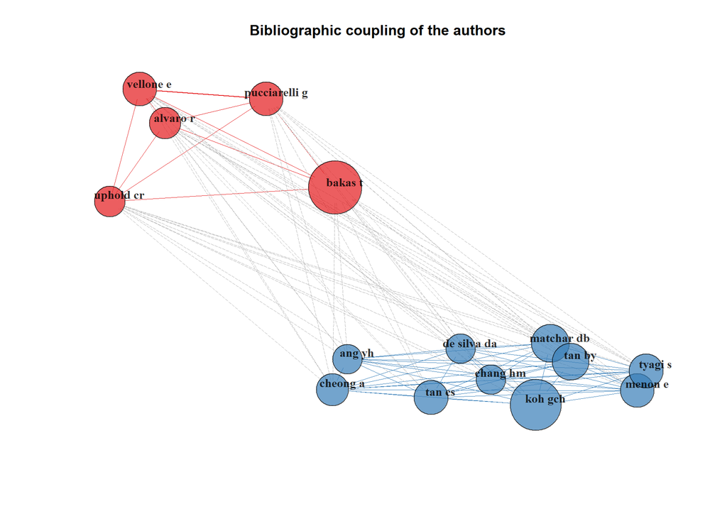

Figure 7: Author Coupling Analysis

```r
bib_AuCoupling_NetMatrix <- biblioNetwork(bibds_wos, analysis = "coupling",
                                          network = "authors", sep = ";")

bib_AuCoupling_Plot <- networkPlot(bib_AuCoupling_NetMatrix, n = 15,
                                   cluster = "optimal", type = "auto",
                                   size.cex = T, size = 20, remove.multiple = F,
                                   Title = "Bibliographic coupling of the authors",
                                   alpha = .7)
```

## 4.6 Keyword

**Note**

summarise on keyword co-occurence matrix plot

Top 10 of most relevance keywords were shown in Table 7.

```r
cbind(Rank = 1:10,
      bibres_summary$MostRelKeywords) %>%
  kable() %>% kable_classic(full_width = F)
```

Table 7: Top 10 Most Relevance Keyword

| Rank | Author Keywords (DE) | Articles | Keywords-Plus (ID) | Articles |
| --- | --- | --- | --- | --- |
| 1 | STROKE | 279 | SURVIVORS | 113 |
| 2 | CAREGIVERS | 116 | BURDEN | 111 |
| 3 | CAREGIVER | 72 | QUALITY-OF-LIFE | 93 |
| 4 | QUALITY OF LIFE | 48 | HEALTH | 90 |
| 5 | DEPRESSION | 46 | CARE | 81 |
| 6 | REHABILITATION | 41 | FAMILY CAREGIVERS | 75 |
| 7 | BURDEN | 30 | REHABILITATION | 56 |
| 8 | FAMILY CAREGIVERS | 30 | DETERMINANTS | 54 |
| 9 | CAREGIVER BURDEN | 24 | INFORMAL CAREGIVERS | 49 |
| 10 | ANXIETY | 22 | IMPACT | 48 |

Author keyword Trend

[figure not shown]

```r
bib_themeevolution_de <- fieldByYear(bibds_wos, field = "DE",
                                     timespan = c(2013,2022), min.freq = 20,
                                     n.items = 5)
```

The keyword co-occurrence can be plotted as shown in Figure 8

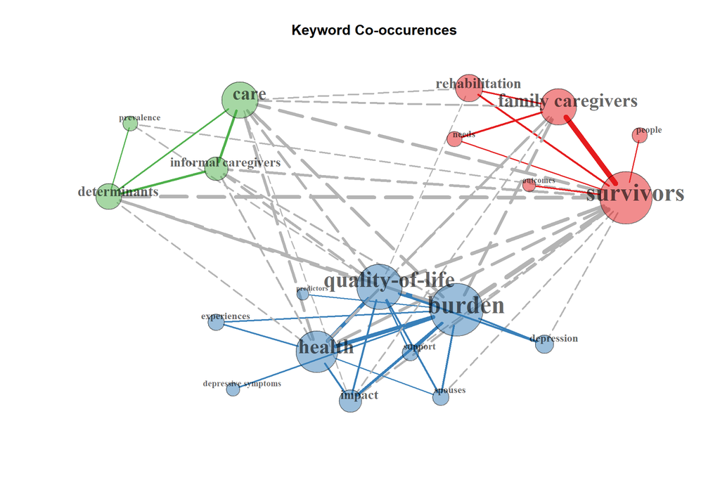

Figure 8: Keyword Co-occurences

```r
bib_kwco_NetMatrix <- biblioNetwork(bibds_wos, analysis = "co-occurrences",
                                     network = "keywords", sep = ";")

bib_kwco_Plot <- networkPlot(bib_kwco_NetMatrix, normalize = "association",
                             n = 20, Title = "Keyword Co-occurences",
                             cluster = "optimal", type = "fruchterman",
                             size.cex = T, size = 20,  remove.multiple = F,
                             edgesize = 7, labelsize = 3, label.cex = T,
                             label.n = 20, edges.min = 10)
```

Thematic Map

[figure not shown]

Figure 9: Thematic Map

```r
bib_thememap <- thematicMap(bibds_wos, field = "DE", n = 500, minfreq = 10,
                            stemming = F, size = .5, n.labels = 5, repel = T)

plot(bib_thememap$map)
```

# 5 Discussion

Demographic ageing is a worldwide process and is associated with an increased prevalence of stroke disease. It is inevitable that family caregivers and caregiver-related problems will increase, because most people with stroke live at home. The *world stroke report* states that the number of people with stroke in need of care is rapidly increasing in developing countries, and our studies show that the studies had fair share of both developed countries and developing countries. National policies and support stroke may play an important role in this phenomenon. For example, US declare stroke a national health priotiry, and was also lunch in other countries. China, the second most productive, indicating that China also make important contribution to this field[^2].

<sup>2</sup> find systematic review on stroke caregiver burden in China

**Note**

UK 2007 National Stroke Strategy

Further analysis show that the most closely cooperating institution were located in the same country and that cooperation among countries was not very common. the variation in health care systems, culture, family structure and care arrangement across countries and regions can lead to different health problem and countermeasures for caregivers, which may be reasons for the lack of international cooperation in this type of research.

**Note**

variation among countries - health services - regarding stroke caregiver

**Note**

WOS: (TI=(stroke) AND TI=(caregiver) AND TI=(trial))

Other than “stroke”, “caregiver” and “burden”, the hotspot analysis show that other widely studied topics include “depression”, “quality of life” and “determinant”. Studies have shown that approximately *30-55%* of caregivers suffer form anxiety or depression symptoms, which may result in changes in their behaviour and reduced quality of care. Although the existing outcome measures predominately focus on the negative aspect of caregiving, the positive aspects of caring, such as self-efficacy, resilience, rewards meaning and spirituality, have been overlooked. The positive aspects of caring could aid in the development of relevant positive psychology interventions. based on the above caregiver health issues, several international agreements and conventions were drafted by the WHO and stroke disease international, and some countries also have policies protecting the rights of caregivers, and national strategies for carers. However, most countries still do not have long-term care services and support for family caregiver of stroke survivors, such as intervention for caregivers health issues.

Several interventional available for caregivers include psychoeducational interventions, supportive interventions, psychotherapy, interventions to improve care r competency and multicomponent intervention.

Additionally, our studies shows that studies are increasingly conducted via the telephone and internet. The use of internet based intervention seem to have great potential and represent a trend for future research.

There were some limitations in this study. FIrst, the data were extracted only from the WOS databse. Second, there were differences between the real research conditions, and the bibliometric analysis results, since some recently published studies were not included. Furthermore, the bibliometric mapping and thematic analysis were performed on the abstract of the information sources only; it is thus possible that the results sould have been diffeent of the publications had been analyzed in their entirety.

# 6 Conclusion

An overview of research on health interventions for stroke caregivers was presented, providing information related to the number of annual publications, countries, journals, institutions, authors and research trends. There is an uregent global unmet need for effective scalable interventions for caregiver of peopele with stroke, given the fast moving pace of this research area. We believe that the key to improve health of family caregivers of stroke survivors lies in unique combination of global solutions and local knowledge. International cooperation should be strengthened to solve this problem. Future research needs the generalisation of treatment effects in different countries and caregivers of stroke survivors need to be addressed. Furthermore, it is evident that RCT evidence is only a part of the current body of evidence; more attention to non-RCT evicence may substantitally help future trial designs, and a realist review could be undertaken to enhance our understanding of the complexity of the implementation and impacts of intervention.

In summary, we identify and analyzed the characteristic of the research on the health of and interventions for stroke survivors caregivers. The result may help guide researchers and funding agencies to the most important research areas in the field.

# 7 Supplementary

## 7.1 Co-citation Network

### 7.1.1 References

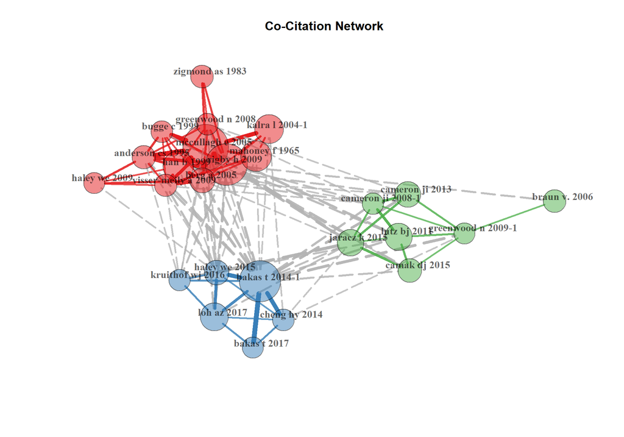

Figure 10: Article Co-citation Analysis

```r
bib_ArCo_NetMatrix <- biblioNetwork(bibds_wos, analysis = "co-citation",
                                    network = "references", sep = ";")

bib_ArCo_Plot <- networkPlot(bib_ArCo_NetMatrix, n = 25,
                             Title = "Co-Citation Network", type = "fruchterman",
                             size.cex = T,  size = 20, remove.multiple = F,
                             labelsize = 1, edgesize = 10, edges.min = 5)
```

## 7.2 Histiograph

Historical Direct Citation Network for 20 authors as shown in Figure 11

```r
bib_histResults <- histNetwork(bibds_wos, sep = ";")
bib_historio_plot <- histPlot(bib_histResults, n = 20, size = 5, labelsize = 4)
```

[figure not shown]

Figure 11: Historical Direct Citation Network

```r
bib_historio_plot$g
```

## 7.3 Co-word Analysis through Correspondence Analysis

[figure not shown]

[figure not shown]

[figure not shown]

[figure not shown]

```r
bib_CS_Plot <- conceptualStructure(bibds_wos, method = "MCA", field = "ID",
                                   minDegree = 15, clust = 5, stemming = F,
                                   labelsize = 15, documents = 20)
```

## 7.4 Other Author’s related Analysis

### 7.4.1 Author dominance ranking

```r
dominance(bibres, k = 10) %>%
  mutate(Author = str_to_title(Author)) %>%
  kable() %>%
  kable_classic(full_width = F)
```

Table 8: Top 10 Author Dominance

| Author | Dominance Factor | Tot Articles | Single-Authored | Multi-Authored | First-Authored | Rank by Articles | Rank by DF |
| --- | --- | --- | --- | --- | --- | --- | --- |
| Tyagi S | 1.0000000 | 7 | 0 | 7 | 7 | 6 | 1 |
| Pucciarelli G | 0.8000000 | 10 | 0 | 10 | 8 | 2 | 2 |
| Mccarthy Mj | 0.7500000 | 8 | 0 | 8 | 6 | 3 | 3 |
| Mei Y | 0.6666667 | 6 | 0 | 6 | 4 | 8 | 4 |
| Cameron Ji | 0.5000000 | 6 | 0 | 6 | 3 | 8 | 5 |
| Forster A | 0.5000000 | 6 | 0 | 6 | 3 | 8 | 5 |
| Bakas T | 0.3076923 | 13 | 0 | 13 | 4 | 1 | 7 |
| Haley We | 0.2857143 | 7 | 0 | 7 | 2 | 6 | 8 |
| Lutz Bj | 0.1250000 | 8 | 0 | 8 | 1 | 3 | 9 |
| Roth Dl | 0.1250000 | 8 | 0 | 8 | 1 | 3 | 9 |

### 7.4.2 Author H-Index

```r
bib_authors <- gsub(","," ",names(bibres$Authors))

bib_hindex <- Hindex(bibds_wos, field = "author", elements = bib_authors,
                    sep = ";", years = 20)

bib_hindex$H %>%
  arrange(desc(h_index),desc(TC)) %>%
  mutate(Element = str_to_title(Element)) %>%
  head(n = 10) %>%
  kable(digits = 2) %>%
  kable_classic(full_width = F)
```

| Element | h_index | g_index | m_index | TC | NP | PY_start |
| --- | --- | --- | --- | --- | --- | --- |
| Bakas T | 8 | 13 | 0.8 | 176 | 13 | 2013 |
| Pucciarelli G | 6 | 10 | NA | 230 | 10 | NA |
| Vellone E | 6 | 10 | NA | 230 | 10 | NA |
| Forster A | 6 | 6 | 0.6 | 226 | 6 | 2013 |
| Cameron Ji | 6 | 6 | 0.6 | 193 | 6 | 2013 |
| Lutz Bj | 6 | 8 | NA | 170 | 8 | NA |
| Dickerson J | 5 | 5 | 0.5 | 209 | 5 | 2013 |
| Alvaro R | 5 | 9 | NA | 194 | 9 | NA |
| Roth Dl | 5 | 8 | 0.5 | 166 | 8 | 2013 |
| Haley We | 5 | 7 | 0.5 | 150 | 7 | 2013 |

## 7.5 Author Production over Time

[figure not shown]

```r
bib_topAUtime <- authorProdOverTime(bibds_wos, k = 30)
```

## Reuse

https://creativecommons.org/licenses/by/4.0/